# Penn Medicine Surveillance Sequencing of SARS-CoV-2 Variants

As SARS-CoV-2 grows, the virus occasionally makes mistakes copying its genetic material, and so introduces heritable changes. As the virus spreads in people, chance changes that increase replication in humans may lead to new variants that spread preferentially. It is important to track these variants in order to understand their possible influences on the effectiveness of vaccines and therapies. Researchers at Penn Medicine are carrying out systematic viral whole genome sequencing to track the nature and spread of viral variants in the Delaware Valley. Below we first show a display of recent data from a random cohort of SARS-CoV-2 positive swab or saliva samples (~10% of total positives) from the University of Pennsylvania Health System. Samples primarily originate from southeastern Pennsylvania and southwestern New Jersey, providing an overview of the dynamics in the Delaware Valley. Below that are summaries of all genomes sequenced, and reports on each genome individually.

The output of the sequencing effort to date is:  
Most recent sequencing run: **2021-06-16**  
Total number of sequenced samples: **1,964**  
Sequenced samples with ≥ 95% genome coverage (≥ 5 reads per position): **1,651**  
Resources: Full tree | Sequenced lineages | Mutation tables | Mutant positions | Run stats | Report archive (437.0 MB) | [Code base](https://github.com/helixscript/SARS-CoV-2-Philadelphia)

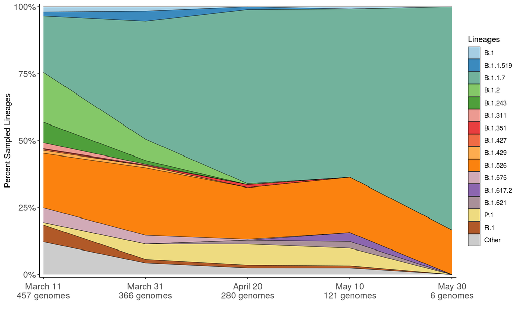

SARS-CoV-2 variants of interest and variants of concern are described in detail by the Centers for Disease Control and Prevention ([here](https://www.cdc.gov/coronavirus/2019-ncov/cases-updates/variant-surveillance/variant-info.html)).  
Methods: samples are sequenced using the Polar Protocol and ARTIC primers, essentially as described in Everett et al. Variant lineages are called using PANGO lineage.  
The display below shows all samples acquired. These include randomly drawns samples, hospitalized cases, vaccine breakthroughs,  
asymptomatics and S drop outs. The later group are selected based on a specific failure of an amplicon targeting the spike coding  
region, which is disrupted by a mutation found in B.1.1.7.

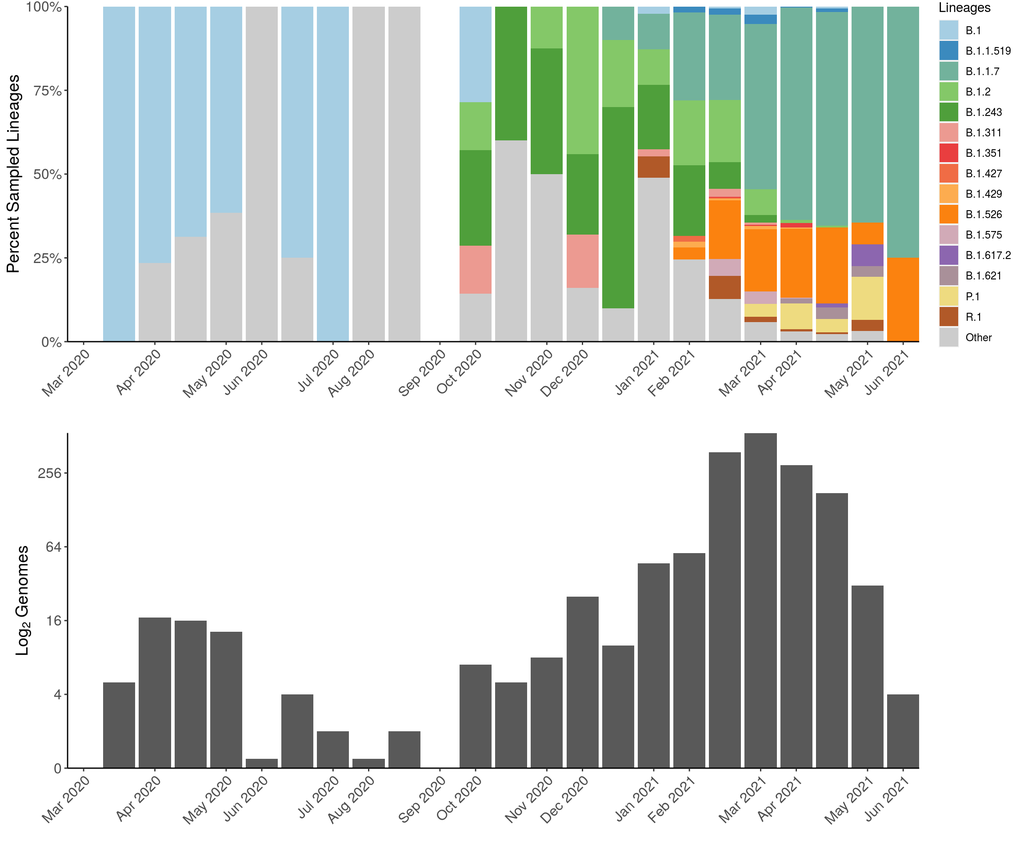

The table below describes all completed genomes including links to sequence analysis reports which provide additional analyses including variant grids and read coverage visualizations.

| Sample | Date | Num. mutations | Lineage | Class | Analysis report | Mutant positions |
| --- | --- | --- | --- | --- | --- | --- |
| VSP2791 | 2021-06-05 | 29 | B.1.526 | Random | link |  |
| VSP2792 | 2021-06-05 | 40 | B.1.1.7 | Random | link |  |
| VSP2793 | 2021-06-05 | 46 | B.1.1.7 | Random | link |  |
| VSP2804 | 2021-06-05 | 39 | B.1.1.7 | Outbreak | link |  |
| VSP2962 | 2021-05-21 | 40 | B.1.1.7 | Random | link |  |
| VSP2949 | 2021-05-20 | 44 | B.1.1.7 | Random | link |  |
| VSP2965 | 2021-05-20 | 43 | B.1.1.7 | Random | link |  |
| VSP2944 | 2021-05-19 | 45 | B.1.1.7 | Random | link |  |
| VSP2945 | 2021-05-19 | 42 | B.1.214.2 | Random | link |  |
| VSP2946 | 2021-05-19 | 41 | B.1.1.7 | Random | link |  |

[output cut: 1641 more lines]

**Contributing authors**  
John K. Everett, Kyle Rodino, Shantan Reddy, Pascha Hokama, Aoife M. Roche, Young Hwang,  
Abigail Glascock, Andrew Marques, Scott Sherrill-Mix, Samantha A. Whiteside, Jevon Graham-Wooten,  
Lisa Mattei, Paige Fenn, Madelyne Om, Ayannah S. Fitzgerald, Mike Feldman, Brendan Kelly,  
Ronald G. Collman, and Frederic Bushman  
**Funding graciously provided by**  
University of Pennsylvania Health System  
Perelman School of Medicine  
Dept. of Pathology and Laboratory Medicine  
Peter Quinn Endowment  
UPenn – Craig Carnaroli  
Penn Center for Research on Coronaviruses and Other Emerging Pathogens  
**Media contact**  
Sophie Kluthe  
Senior Medical Communications Officer  
Penn Medicine  
sophie.kluthe@pennmedicine.upenn.edu  
(267) 588-5939  
**References**  
Everett, John et al. “SARS-CoV-2 Genomic Variation in Space and Time in Hospitalized Patients in Philadelphia.”  
mBio vol. 12,1 e03456-20. 19 Jan. 2021, doi:10.1128/mBio.03456-20